# Who’s that pokemon?

Authors

Maria Briones

Riccardo Dondi

Sayatan Mandal

[figure not shown]

# Our mission: catch them all

A very common issue to every parent is how to advice their 10-year-old child when the kid is about to leave on a world-wide trip. There are many important questions to be adressed before the trip, like “How many pokemons there are?”, “Who is the strongest?” “How do I catch them all?”.

On this document we try to provide some insights on the pokemon world to help parents to advice their children on how to catch them all. We will be using the pokemon dataset from the [tidytuesday repository](https://github.com/rfordatascience/tidytuesday/tree/main), which contains information about all the pokemons from the first generation to the seventh generation.

[figure not shown]

## Data loading and cleaning

First we need to get our R enviroment ready and load the data. We will be using the `tidytuesdayR` package to load the data, which is a great resource for finding interesting datasets to work with.

```r
#load pacman library to load all the libraries and install if needed
library(pacman)

# Load libraries
p_load(tidyverse, #for data manipulation
        ggplot2, #for plotting
        tidytuesdayR, #to load the data
        forcats, #for factor manipulation
        farver, #for color manipulation
        knitr, #for appealing tables
        kableExtra, #for appealing tables
        skimr, #for data exploration
        viridisLite #for color palette
        )

# if we wanted to set a different working directory
# mainwd <- "C:/Users/marub/Desktop/DataSci for Management/Statistics with R/Data Visualization"
```

With our environment ready we import the data and do some cleaning. We will be using the [Pokemon](https://github.com/rfordatascience/tidytuesday/blob/main/data/2025/2025-04-01/readme.md) dataset, which contains information about all the pokemon from the first generation to the seventh generation.

```r
# import data pokemon from tidytuesdayR
pokemon_df <- tt_load(2025, week = 13)$pokemon_df
```

Our databse contains information about 949 pokemons studied on 22 variables, both numerical and categorical.

```r
pokemon_df |> skim()
```

Data summary

| Name | pokemon_df |
| --- | --- |
| Number of rows | 949 |
| Number of columns | 22 |
| _______________________ |  |
| Column type frequency: |  |
| character | 10 |
| numeric | 12 |
| ________________________ |  |
| Group variables | None |

**Variable type: character**

| skim_variable | n_missing | complete_rate | min | max | empty | n_unique | whitespace |
| --- | --- | --- | --- | --- | --- | --- | --- |
| pokemon | 0 | 1.00 | 3 | 23 | 0 | 949 | 0 |
| type_1 | 0 | 1.00 | 3 | 8 | 0 | 18 | 0 |
| type_2 | 439 | 0.54 | 3 | 8 | 0 | 18 | 0 |
| color_1 | 0 | 1.00 | 7 | 7 | 0 | 18 | 0 |
| color_2 | 439 | 0.54 | 7 | 7 | 0 | 18 | 0 |
| color_f | 439 | 0.54 | 7 | 7 | 0 | 155 | 0 |
| egg_group_1 | 0 | 1.00 | 3 | 13 | 0 | 15 | 0 |
| egg_group_2 | 711 | 0.25 | 3 | 13 | 0 | 12 | 0 |
| url_icon | 228 | 0.76 | 55 | 55 | 0 | 721 | 0 |
| url_image | 0 | 1.00 | 83 | 85 | 0 | 949 | 0 |

**Variable type: numeric**

| skim_variable | n_missing | complete_rate | mean | sd | p0 | p25 | p50 | p75 | p100 | hist |
| --- | --- | --- | --- | --- | --- | --- | --- | --- | --- | --- |
| id | 0 | 1.00 | 1899.77 | 3507.95 | 1.0 | 238.0 | 475.0 | 712.0 | 10147.0 | ▇▁▁▁▂ |
| species_id | 0 | 1.00 | 400.13 | 239.95 | 1.0 | 191.0 | 395.0 | 615.0 | 802.0 | ▇▇▇▆▇ |
| height | 0 | 1.00 | 1.23 | 1.27 | 0.1 | 0.5 | 1.0 | 1.5 | 14.5 | ▇▁▁▁▁ |
| weight | 0 | 1.00 | 66.21 | 119.95 | 0.1 | 8.5 | 28.8 | 66.6 | 999.9 | ▇▁▁▁▁ |
| base_experience | 0 | 1.00 | 150.48 | 76.39 | 36.0 | 68.0 | 157.0 | 184.0 | 608.0 | ▇▇▂▁▁ |
| hp | 0 | 1.00 | 68.95 | 25.93 | 1.0 | 50.0 | 65.0 | 80.0 | 255.0 | ▃▇▁▁▁ |
| attack | 0 | 1.00 | 79.47 | 31.95 | 5.0 | 55.0 | 75.0 | 100.0 | 190.0 | ▂▇▆▂▁ |
| defense | 0 | 1.00 | 74.07 | 30.76 | 5.0 | 50.0 | 70.0 | 90.0 | 230.0 | ▃▇▃▁▁ |
| special_attack | 0 | 1.00 | 72.81 | 32.63 | 10.0 | 50.0 | 65.0 | 95.0 | 194.0 | ▅▇▅▂▁ |
| special_defense | 0 | 1.00 | 72.22 | 27.68 | 20.0 | 50.0 | 70.0 | 90.0 | 230.0 | ▇▇▂▁▁ |
| speed | 0 | 1.00 | 69.02 | 29.21 | 5.0 | 45.0 | 65.0 | 90.0 | 180.0 | ▃▇▆▂▁ |
| generation_id | 147 | 0.85 | 3.69 | 1.93 | 1.0 | 2.0 | 4.0 | 5.0 | 7.0 | ▇▅▃▅▅ |

Not all of these features contain valuable information for our analysis, so we will be selecting only the ones that we think are relevant:

- id: the id of the pokemon
- pokemon: the name of the pokemon
- height: the height of the pokemon in meters
- weight: the weight of the pokemon in kilograms
- base_experience: the base experience of the pokemon when catched
- type_1: the primary type of the pokemon
- type_2: the secondary type of the pokemon (if it has one)
- hp: the health points of the pokemon
- attack: the attack points of the pokemon
- defense: the defense points of the pokemon
- special_attack: the special attack points of the pokemon
- special_defense: the special defense points of the pokemon
- speed: the speed points of the pokemon
- generation_id: the generation on wich the pokemon was introduced

```r
# drop columns that we don't need and which have many NAs
pokemon_df <- pokemon_df |>
  select(-c(color_2,color_f,egg_group_2,species_id, url_icon, url_image))
```

[figure not shown]

One of the first things we notice is that there are some missing values (NA) on the generation_id variable (exactly 147). After some research on this subset we were able to determine that these pokemons are all spetial edition pokemons like Charizard Mega X or Pikachu Pop Star. In consequence we will be dropping these pokemons from our analysis, since they are not representative of the general pokemon population and they could mislead our insights.

```r
# drop pokemons with missing generation_id
pokemon_df = pokemon_df |>
  filter(!is.na(generation_id))
```

[figure not shown]

Now we have a clean dataset with 802 pokemons and 16 variables.

# 3 insights on the pokemon world

## 1. Dual-type vs Single-type

Dual-type Pokémon consistently outperform single-types in raw power. We engineer `is_dual_type`, then group and summarise to quantify the gap.

```r
df <- pokemon_df |>
  mutate(
    type_2       = na_if(type_2, "NA"),
    is_dual_type = !is.na(type_2),
    total_stats  = hp + attack + defense + special_attack + special_defense + speed
  )

dual_summary <- df |>
  group_by(is_dual_type) |>
  summarise(
    n            = n(),
    mean_total   = round(mean(total_stats), 1),
    median_total = round(median(total_stats), 1),
    sd_total     = round(sd(total_stats), 1),
    .groups = "drop"
  )

dual_summary |>
  kable(
    caption = "Summary Statistics by Dual-Type Status",
    col.names = c("Dual Type?", "Count", "Mean Total", "Median Total", "SD Total")
  ) |>
  kable_styling(bootstrap_options = c("striped", "hover", "condensed"),
                full_width = FALSE)
```

Summary Statistics by Dual-Type Status

| Dual Type? | Count | Mean Total | Median Total | SD Total |
| --- | --- | --- | --- | --- |
| FALSE | 400 | 403.8 | 405 | 109.8 |
| TRUE | 402 | 438.4 | 460 | 109.3 |

```r
# Break it down further by primary type
type_dual <- df |>
  group_by(type_1, is_dual_type) |>
  summarise(
    n          = n(),
    mean_total = round(mean(total_stats), 1),
    .groups    = "drop"
  ) |>
  filter(n >= 5) |>
  arrange(desc(mean_total))


type_dual |> slice_head(n = 10) |>
  kable(
    caption = "Mean Total Stats by Primary Type and Dual-Type Status",
    col.names = c("Primary Type", "Dual Type?", "Count", "Mean Total")
  ) |>
  kable_styling(bootstrap_options = c("striped", "hover", "condensed"),
                full_width = FALSE)
```

Mean Total Stats by Primary Type and Dual-Type Status

| Primary Type | Dual Type? | Count | Mean Total |
| --- | --- | --- | --- |
| dragon | TRUE | 15 | 568.0 |
| fire | TRUE | 22 | 490.5 |
| psychic | TRUE | 18 | 484.4 |
| steel | TRUE | 20 | 477.9 |
| fighting | TRUE | 7 | 469.7 |
| electric | TRUE | 12 | 463.2 |
| rock | TRUE | 34 | 450.4 |
| dark | TRUE | 20 | 447.3 |
| ground | TRUE | 17 | 440.7 |
| ice | FALSE | 12 | 438.6 |

[figure not shown]

## 2. Pokemon distribution by generation

Now is time to adress some of our questions: How many pokemons there are in each generation? How powerfull are they? We can get some ideas about these topics by looking at the distribution of pokemons.

```r
# to a better analysis we create to combined variables
pokemon_df = pokemon_df |>
  mutate(comb_attack = attack + special_attack,
         comb_defense = defense + special_defense)

#summarise pokemon distribution by generation and main stats
interest_stats = pokemon_df |>
  group_by(generation_id) |>
  summarise(n = n(),
            avg_hp = mean(hp, na.rm = TRUE),
            avg_attack = mean(comb_attack, na.rm = TRUE),
            avg_defense = mean(comb_defense, na.rm = TRUE),
            avg_speed = mean(speed, na.rm = TRUE)
)
```

Table 1: Pokemon stats by generation

| generation_id | n | avg_hp | avg_attack | avg_defense | avg_speed |
| --- | --- | --- | --- | --- | --- |
| 1 | 151 | 64.21 | 140.05 | 134.31 | 69.07 |
| 2 | 100 | 70.98 | 132.76 | 142.03 | 61.41 |
| 3 | 135 | 65.67 | 140.97 | 135.47 | 61.61 |
| 4 | 107 | 73.10 | 153.50 | 149.68 | 69.48 |
| 5 | 156 | 70.31 | 150.28 | 138.57 | 66.60 |
| 6 | 72 | 68.92 | 145.04 | 149.94 | 65.68 |
| 7 | 81 | 70.69 | 156.68 | 151.89 | 64.54 |

From this we can see that the most populated generations are the 1st, 3rd and 5th. Nevertheless, the most powerfull generation considering all four stats (combined attack, combined defense, hp and speed) is the 4th generation.

## 3. What can we say about types

Pokemons come on a wide variety of types. Does it matter to pick a pokemon of a certain type? Are some types more common than others? Are some types more powerful than others? These are very important questions as we know that advantages and weaknesses of types are a key element of the pokemon world. For example, water type pokemons are strong against fire type pokemons but weak against electric type pokemons. In consequence, if we want to catch them all we need to know which types are more common and which types are more powerful.

```r
#table for count of pokemon by type and generation
pokemon_df |>
  group_by(generation_id, type_1) |>
  summarise(n = n()) |>
  pivot_wider(names_from = generation_id, values_from = n, values_fill = 0) |>
  mutate(Total = rowSums(across(where(is.numeric)))) |>
  kable() %>%
  kable_styling(bootstrap_options = c("striped", "hover", "condensed", "responsive"),
                full_width = F, position = "center")
```

Table 2: Number of Pokemons by type and generation

| type_1 | 1 | 2 | 3 | 4 | 5 | 6 | 7 | Total |
| --- | --- | --- | --- | --- | --- | --- | --- | --- |
| bug | 12 | 10 | 12 | 8 | 18 | 3 | 9 | 72 |
| dragon | 3 | 0 | 7 | 3 | 7 | 4 | 3 | 27 |
| electric | 9 | 6 | 4 | 7 | 7 | 3 | 3 | 39 |
| fairy | 2 | 5 | 0 | 1 | 0 | 9 | 1 | 18 |
| fighting | 7 | 2 | 4 | 2 | 7 | 3 | 4 | 29 |
| fire | 12 | 8 | 6 | 5 | 8 | 8 | 5 | 52 |
| ghost | 3 | 1 | 4 | 6 | 5 | 4 | 4 | 27 |
| grass | 12 | 9 | 12 | 13 | 15 | 5 | 12 | 78 |
| ground | 8 | 3 | 6 | 4 | 9 | 0 | 2 | 32 |
| ice | 2 | 4 | 6 | 3 | 6 | 2 | 0 | 23 |
| normal | 22 | 15 | 18 | 17 | 17 | 4 | 12 | 105 |
| poison | 14 | 1 | 3 | 6 | 2 | 2 | 4 | 32 |
| psychic | 8 | 7 | 8 | 7 | 14 | 3 | 6 | 53 |
| rock | 9 | 4 | 8 | 6 | 6 | 8 | 4 | 45 |
| water | 28 | 18 | 24 | 13 | 17 | 5 | 9 | 114 |
| dark | 0 | 5 | 4 | 3 | 13 | 3 | 1 | 29 |
| steel | 0 | 2 | 9 | 3 | 4 | 4 | 2 | 24 |
| flying | 0 | 0 | 0 | 0 | 1 | 2 | 0 | 3 |

# Vizualizations

## 1. Type proportion on our sample

The analysis can be enriched if we consider the secondary type of pokemons. Considerin the 18 main types and the 19 secondary types (including “None”) there are 342 possible combinations we can create a heatmap to visualize the proportion of pokemons by type 1 and type 2 across the total universe of registered pokemons. This will allow us to see which combinations of types are more common and which are more rare.

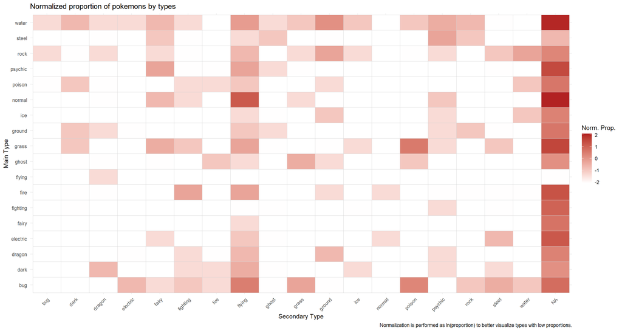

```r
# count of pokemon by type 1 and type 2
poke_type <- pokemon_df|>
  group_by(type_1, type_2) |>
  summarise(n = n(), .groups = "drop") |>
  complete(type_1, type_2, fill = list(n = 0)) |>
  ungroup() |>
  mutate(prop = n * 100 / sum(n),
         norm_prop = case_when (prop==0 ~ -2.1,
                                TRUE ~ log(prop))
        )

poke_type <- poke_type |>
  mutate(type_2 = fct_relevel(type_2, "None")) #we make it a factor so "None" appears first

#graph
ggplot(poke_type, aes(x = type_2, y = type_1, fill = norm_prop)) +
  geom_tile(color = "lightgrey") +
  scale_fill_gradient(low = "white", high = "#B22222") +
  labs(
    title = "Normalized proportion of pokemons by types",
    x = "Secondary Type",
    y = "Main Type",
    fill = "Norm. Prop.",
    caption = "Normalization is performed as ln(proportion) to better visualize types with low proportions."
  ) +
  theme_minimal() +
  theme(axis.text.x = element_text(angle = 45, hjust = 1))
```

Assuming that each pokemon species distributed homogeneously across the world, meaning that for example catching a Blastoise is as likely as catching a Squirtle (strong assumption), we could say that the most abuntant pokemons belong to the Water-None combination. Outside the None secondary type, the most common combinations are Normal-Flying (like Pidgey), Grass-Poison (like Bulbasaur) and Bug-Flying (like Butterfree). On the other hand, there are 42 combinations that have only one pokemon species, like the Ghost-Fairy, Fire-Dark, or Dragon-Electric.

## 2. Single vs Dual-type stat distributions

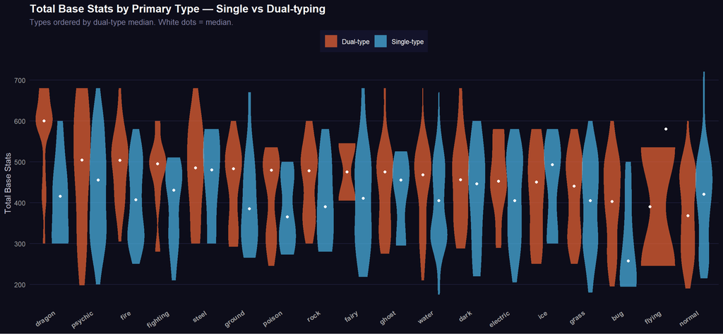

```r
# Order types by median total stats (dual-type)
type_order <- df |>
  filter(is_dual_type) |>
  group_by(type_1) |>
  summarise(med = median(total_stats), .groups = "drop") |>
  arrange(desc(med)) |>
  pull(type_1)

df |>
  mutate(
    type_1       = factor(type_1, levels = type_order),
    typing_label = if_else(is_dual_type, "Dual-type", "Single-type")
  ) |>
  ggplot(aes(x = type_1, y = total_stats, fill = typing_label)) +
  geom_violin(
    position = position_dodge(width = 0.85),
    alpha = 0.65, colour = NA, scale = "width"
  ) +
  stat_summary(
    aes(group = typing_label),
    fun = median, geom = "point", shape = 21,
    colour = "white", fill = "white", size = 1.5,
    position = position_dodge(width = 0.85)
  ) +
  scale_fill_manual(
    values = c("Single-type" = "#4FC3F7", "Dual-type" = "#FF6B35")
  ) +
  scale_y_continuous(breaks = seq(100, 800, 100)) +
  labs(
    title    = "Total Base Stats by Primary Type — Single vs Dual-typing",
    subtitle = "Types ordered by dual-type median. White dots = median.",
    x = NULL, y = "Total Base Stats", fill = NULL
  ) +
  theme_minimal(base_size = 11) +
  theme(
    plot.background  = element_rect(fill = "#0D0D1A", colour = NA),
    panel.background = element_rect(fill = "#0D0D1A", colour = NA),
    panel.grid.major.y = element_line(colour = "#1E1E3A"),
    panel.grid.major.x = element_blank(),
    panel.grid.minor   = element_blank(),
    axis.text   = element_text(colour = "#9E9EA0"),
    axis.text.x = element_text(angle = 35, hjust = 1, face = "bold"),
    axis.title  = element_text(colour = "#C0C0D0"),
    plot.title    = element_text(colour = "white", face = "bold", size = 14),
    plot.subtitle = element_text(colour = "#7B7B9E", size = 10),
    legend.background = element_rect(fill = "#13132A", colour = NA),
    legend.text  = element_text(colour = "white"),
    legend.position = "top"
  )
```

**Reading the chart:** Nearly every type shows the orange (dual-type) violin sitting higher than the blue (single-type) one. Dragon dual-types are especially concentrated at the top; Normal single-types show the widest spread due to a large pool of filler Pokémon.

## 3. Distribution of stats by type

We had done a visualization on the distribituion of stats w.r.t the generation but we did not see any changes that made sense as the generation increased.

So we try to see the different stats of different types of pokemons and we can look at the graph and find out the Strongest , Weakest , Slowest or Fastest types of pokemons.

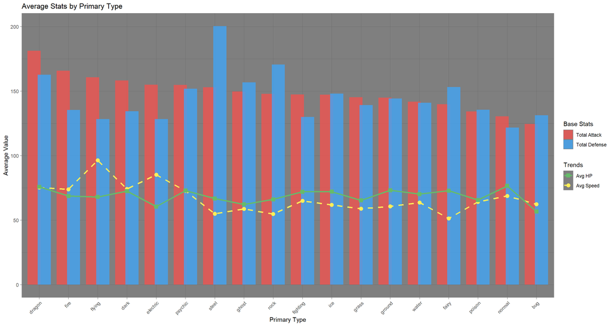

```r
#new interest stats by type
# 1. Aggregate data by Type only
type_summary <- df %>%
  group_by(type_1) %>%
  summarise(
    # Calculate the means of the sums directly
    attack_total  = mean(attack + special_attack, na.rm = TRUE),
    defense_total = mean(defense + special_defense, na.rm = TRUE),
    speed         = mean(speed, na.rm = TRUE),
    hp            = mean(hp, na.rm = TRUE),
    .groups = "drop"
  ) %>%
  arrange(desc(attack_total)) %>%
  mutate(type_1 = factor(type_1, levels = type_1))

# 2. Pivot (Note: Ensure the names match your new columns)
type_long <- type_summary %>%
  pivot_longer(
    cols = c(attack_total, defense_total),
    names_to = "stat_name",
    values_to = "stat_value"
  )

# 3. Plot
ggplot() +
  geom_col(
    data = type_long,
    aes(x = type_1, y = stat_value, fill = stat_name),
    position = position_dodge(width = 0.7), alpha = 0.8
  ) +
  # Dashed line for Speed
  geom_line(
    data = type_summary,
    aes(x = type_1, y = speed, group = 1, color = "Avg Speed"),
    linewidth = 1.2, linetype = "dashed"
  ) +
  # Solid line for HP
  geom_line(
    data = type_summary,
    aes(x = type_1, y = hp, group = 1, color = "Avg HP"),
    linewidth = 1.2
  ) +
  geom_point(data = type_summary, aes(x = type_1, y = speed, color = "Avg Speed"), size = 3, shape = 16) +
  geom_point(data = type_summary, aes(x = type_1, y = hp, color = "Avg HP"), size = 3, shape = 15) +
  scale_fill_manual(
    values = c("attack_total" = "#EF5350", "defense_total" = "#42A5F5"), # Updated names
    labels = c("Total Attack", "Total Defense"),
    name = "Base Stats"
  ) +
  scale_color_manual(
    values = c("Avg Speed" = "#FFEE58", "Avg HP" = "#66BB6A"),
    name = "Trends"
  ) +
  theme_dark() +
  theme(axis.text.x = element_text(angle = 45, hjust = 1))+
  labs(
    title = "Average Stats by Primary Type",
    x = "Primary Type",
    y = "Average Value"
  )
```

[figure not shown]

The strongest pokemon according to POKEDEX

# Conclusion

After exploring the Pokémon universe across types, generations, and stat distributions, we can finally offer some battle-tested advice to any 10-year-old setting out on their journey.

**Dual-type Pokémon are worth the extra effort.**

**The bottom line:** Prioritise dual-type Pokémon, pay attention to generation 4, and do not underestimate type synergy. And after all of this very fancy analysis — we are still betting on Pikachu. ⚡